# ANCOVA

**Universidad Nacional Autonoma de México**

**Facultad de Ciencias**

**Seminario de Estadística I**

Autor: Zárate Almaguer Francisco Javier

#### Contenido

Implementación

Análisis Exploratorio de Datos

Ajuste del modelo

Reducción del modelo

Modelo reducido

Verificación de los supuestos

- ANCOVA es un tipo de modelo lineal general (GLM) que incluye al menos una variable independiente continua y una categórica (tratamientos). ANCOVA es útil cuando el efecto de los tratamientos es importante mientras hay una variable continua adicional en el estudio. ANCOVA es propuesto por el estadístico británico Ronald A. Fisher durante la década de 1930.
- La variable independiente continua adicional en ANCOVA se denomina covariable (también conocida como variable de control, concomitante o de confusión).
- ANCOVA estima las diferencias entre grupos en una variable independiente categórica (interés primario) ajustando estadísticamente el efecto de la covariable (eliminando la varianza asociada a la covariable). ANCOVA aumenta el poder estadístico y reduce el término de error al eliminar la varianza asociada con la covariable.
- ANCOVA proporciona medias ajustadas (que están controladas estadísticamente por covariables) para cada grupo en una variable independiente categórica. Los medios ajustados eliminan el sesgo de la covariable del modelo.
- ANCOVA utiliza el enfoque de regresión múltiple (como la regresión simple en ANOVA) para estudiar los efectos ajustados de la variable independiente sobre la variable dependiente.

## Supuestos de ANCOVA Enlace permanente

ANCOVA sigue suposiciones similares a las de ANOVA para la independencia de las observaciones, la normalidad y la homogeneidad de las varianzas. Además, ANCOVA debe cumplir con los siguientes supuestos,

- Suposición de linealidad : en cada nivel de variable independiente categórica, la covariable debe estar linealmente relacionada con la variable dependiente. Si la relación no es lineal, el ajuste realizado a la covariable estará sesgado.
- Homogeneidad de las pendientes de regresión dentro del grupo (paralelismo o no interacción) : No debe haber interacción entre la variable independiente categórica y la covariable, es decir, las líneas de regresión entre la covariable y la variable dependiente para cada grupo de la variable independiente deben ser paralelas (misma pendiente ).
- La variable dependiente y la covariable deben medirse en una escala continua

La covariable debe medirse sin error o con el menor error posible.

## Implementación

### Datos

Algunos investigadores están interesados en comparar la efectividad de tres tratamientos para tratar la depresión. Por simplicidad, se denotan los tres tratamientos como tratamiento A, B y C. Los investigadores recolectaron información al respecto a través de una muestra aleatoria de tamaño *n = 36* de individuos con depresión.

#### Variables

- $y_i := \text{ Medida de efectivdad del tratamiento para el individuo } i$
- $x_{i,1} := \text{ Edad (en años) del individuo } i$
- $x_{i,j} =\begin{cases} 1, & \text{ si el individuo } i \text{ recibio el tratamiento } j, j=\left \{ A,B,C \right \} \\ 0 & \text{ c.o.c } . \end{cases}$
- Paso 1: cree un DataFrame de datos de Pandas para almacenar los datos para realizar ANCOVA.

```python
# Comenzamos por cargar las librerias que ocuparemos
import numpy as np
import pandas as pd
import statsmodels.api as sm
from statsmodels.formula.api import ols
import matplotlib.pyplot as plt
```

después, cargamos los datos en un dataframe

```python
df = pd.read_table("Datos.txt")
df.head()
```

|  | y | age | x2 | x3 | TRT |
| --- | --- | --- | --- | --- | --- |
| 0 | 56 | 21 | 1 | 0 | A |
| 1 | 41 | 23 | 0 | 1 | B |
| 2 | 40 | 30 | 0 | 1 | B |
| 3 | 28 | 19 | 0 | 0 | C |
| 4 | 55 | 28 | 1 | 0 | A |

Donde las variables `x2` y `x3` corresponde a variables indicadoras referentes a si el individuo recibió el tratamiento A o B respectivamente. Notemos que nos falta una variable indicadora que haga referencia al tratamiento *C*, por lo tanto procedemos a generarla

```python
# Si el individuo ha recibido el tratamiento C, entonces asignaremos el valor
# de 1, caso contrario asignaremos el valor de 0
def trat_C(tratamiento):
    if tratamiento == "C":
        return 1
    else:
        return 0
```

```python
# Agregamos una columna nueva y aplicamos la funcion anterior
# a cada una de las filas de la columna (serie) TRT
df["xC"] = df["TRT"].apply(lambda x: trat_C(x))
df.head()
```

|  | y | age | x2 | x3 | TRT | xC |
| --- | --- | --- | --- | --- | --- | --- |
| 0 | 56 | 21 | 1 | 0 | A | 0 |
| 1 | 41 | 23 | 0 | 1 | B | 0 |
| 2 | 40 | 30 | 0 | 1 | B | 0 |
| 3 | 28 | 19 | 0 | 0 | C | 1 |
| 4 | 55 | 28 | 1 | 0 | A | 0 |

Ahora procedamos a renombrar las variables, para un mayor entendimiento.

```python
df = df.rename(columns={'age':'x1',
                        "TRT" : "tratamiento",
                        "x2" : "xA",
                        "x3" : "xB"})
df.head()
```

|  | y | x1 | xA | xB | tratamiento | xC |
| --- | --- | --- | --- | --- | --- | --- |
| 0 | 56 | 21 | 1 | 0 | A | 0 |
| 1 | 41 | 23 | 0 | 1 | B | 0 |
| 2 | 40 | 30 | 0 | 1 | B | 0 |
| 3 | 28 | 19 | 0 | 0 | C | 1 |
| 4 | 55 | 28 | 1 | 0 | A | 0 |

### Análisis exploratorio

Procedamos a ver que sucede con los datos.

```python
# Algunas caracteristicas sobre la columna tratamiento
df["tratamiento"].describe()
```

```
count     36
unique     3
top        A
freq      12
Name: tratamiento, dtype: object
```

```python
# Veamos dichas caracteristicas para cada una de las columnas
for i in df.columns:
    print(df[i].describe(), end = "\n", sep = "|")
```

```
count    36.000000
mean     55.166667
std      12.415428
min      25.000000
25%      46.750000
50%      58.000000
75%      63.250000
max      73.000000
Name: y, dtype: float64
count    36.000000
mean     44.111111
std      14.628305
min      19.000000
25%      32.250000
50%      44.000000
75%      56.500000
max      67.000000
Name: x1, dtype: float64
count    36.000000
mean      0.333333
std       0.478091
min       0.000000
25%       0.000000
50%       0.000000
75%       1.000000
max       1.000000
Name: xA, dtype: float64
count    36.000000
mean      0.333333
std       0.478091
min       0.000000
25%       0.000000
50%       0.000000
75%       1.000000
max       1.000000
Name: xB, dtype: float64
count     36
unique     3
top        A
freq      12
Name: tratamiento, dtype: object
count    36.000000
mean      0.333333
std       0.478091
min       0.000000
25%       0.000000
50%       0.000000
75%       1.000000
max       1.000000
Name: xC, dtype: float64
```

```python
# Datos agrupados por efectividad

# Consideraremos solo las columnas del tratamiento
# y la efectividad
grupos = df[["tratamiento", "y"]]
# Agrupamos por tratamiento y observamos algunas caracteristicas
# por tratamiento y efectividad
grupos.groupby('tratamiento').describe()
```

| tratamiento | y count | y mean | y std | y min | y 25% | y 50% | y 75% | y max |
| --- | --- | --- | --- | --- | --- | --- | --- | --- |
| A | 12.0 | 62.333333 | 6.386539 | 52.0 | 57.50 | 62.5 | 66.00 | 73.0 |
| B | 12.0 | 51.916667 | 8.360713 | 40.0 | 45.75 | 51.5 | 58.50 | 64.0 |
| C | 12.0 | 51.250000 | 17.189452 | 25.0 | 35.50 | 54.5 | 64.25 | 71.0 |

```python
# Varianza de la efectividad por tratamiento
grupos.groupby('tratamiento').var()
```

| tratamiento | y |
| --- | --- |
| A | 40.787879 |
| B | 69.901515 |
| C | 295.477273 |

Muestralmente observamos lo siguiente:

- El número de observaciones es el mismo $(n = 12)$ para cada Tratamiento.
- En promedio la efectividad del tratamineto $A$ es de 62.33, la del tratamiento $B$ es de 51.92 y por último la del tratamiento $C$ es de 51.25.
- Notamos mayor variabilidad de la efectividad en los datos del tratamiento $C$ y menor variabilidad en los datos del tratamiento $A$.

Procedemos a realizar un análisis gráfico de nuestros datos:

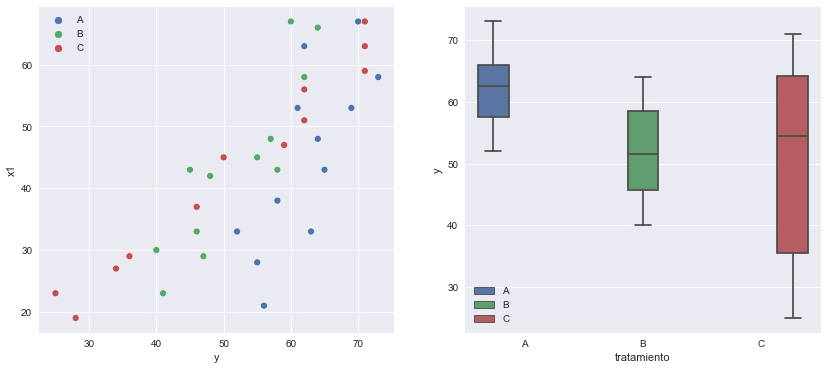

```python
import seaborn as sns
import matplotlib.pyplot as plt

# Configuramos un estilo de graficacion
plt.style.use('seaborn')

# Configuramos el tamagnio de salida de nuestros graficos
plt.rcParams['figure.figsize'] = [14, 6]

# Mostraremos dos graficos
fig, axs = plt.subplots(ncols=2)

sns.scatterplot(data=df, x="y", y="x1", hue=df.tratamiento.tolist(), ax=axs[0])
sns.boxplot(data=df, x="tratamiento", y="y", hue=df.tratamiento.tolist(), ax=axs[1])
plt.show()
```

La gráfica anterior sugiere que la $edad$ influye en la Efectividad de cada tratamiento (se nota una pendiente $\neq$ 0 en cada uno de los grupos).

Visualmente observamos lo siguiente:

- Para edades menores a 40 años, la efectividad del tratamiento A parece ser la mejor, la efectividad del tratamiento B parece ser la segunda mejor y la peor efectividad parece ser la del tratamiento C.
- Para edades mayores a 40 años, no parece que la eficacia sea diferente dependiento del tratamiento.

## ANCOVA

El modelo de *RLM* con interacciones esta parametrizado de la siguiente manera

$y_i = \beta_0 + \underbrace{\beta_1 x_{i,1}}_{Edad} + \underbrace{\beta_2 x_{i,B} + \beta_3 x_{i,C}}_{Tratamiento} + \underbrace{\beta_4 x_{i,B}x_{i,1} + \beta_5 x_{i.1}x_{i,C}}_{Tratamiento} + \epsilon_i$

donde $\epsilon_i \sim \text{N}\left ( 0, \sigma^2 \right ), \forall i\in \left \{ 1 , \dots , n \right \}. $

Observación: En la parametrización del modelo se consideró al tratamiento A como el nivel de referencia, entonces

- Si el individuo $i$ recibe el tratamiento $A$, entonces $x_{i,B}=0$ y $x_{i,C}=0$

\begin{align*} \hat{\mathbb{E}}\left [ y_i; \text{Tratamiento } A , x_i \right ] &= \hat{\beta}_0 +\hat{\beta_1}x_{i,1} + \hat{\beta_2}*0 + \hat{\beta}_3*0 + \hat{\beta}_4x_{i,1}*0 + \hat{\beta}_5x_{i,1}*0 \\ &= \hat{ \beta}_0 + \hat{\beta}_1x_{i,1} \end{align*}

- Si el individuo $i$ recibe el tratamiento $B$, entonces $x_{i,B}=1$ y $x_{i,C}=0$

\begin{align*} \hat{\mathbb{E}}\left [ y_i; \text{Tratamiento } B , x_i \right ] &= \hat{\beta}_0 +\hat{\beta_1}x_{i,1} + \hat{\beta_2}*1 + \hat{\beta}_3*0 + \hat{\beta}_4x_{i,1}*1 + \hat{\beta}_5x_{i,1}*0 \\ &= \left ( \hat{ \beta}_0 + \hat{\beta}_2 \right ) + \left ( \hat{ \beta}_1 + \hat{\beta}_4 \right )x_{i,1} \end{align*}

- Si el individuo $i$ recibe el tratamiento $C$, entonces $x_{i,B}=0$ y $x_{i,C}=1$

\begin{align*} \hat{\mathbb{E}}\left [ y_i; \text{Tratamiento } C , x_i \right ] &= \hat{\beta}_0 +\hat{\beta_1}x_{i,1} + \hat{\beta_2}*0 + \hat{\beta}_3*1 + \hat{\beta}_4x_{i,1}*0 + \hat{\beta}_5x_{i,1}*1 \\ &= \left ( \hat{ \beta}_0 + \hat{\beta}_3 \right ) + \left ( \hat{ \beta}_1 + \hat{\beta}_5 \right )x_{i,1} \end{align*}

### Ajuste del modelo en python

```python
# Para realizar el ajuste del modelo utilizamos la funcion ols() como sigue
#              ---  modelo ---                          -- Ajuste --
model = ols('y ~ x1 + xB + xC + x1:xB + x1:xC', data=df).fit()

# Veamos la informacion de la tabla anova obtenida de nuestro
# ajuste del modelo anterior
sm.stats.anova_lm(model, typ=2)
```

|  | sum_sq | df | F | PR(>F) |
| --- | --- | --- | --- | --- |
| x1 | 3302.258622 | 1.0 | 214.363829 | 3.331105e-15 |
| xB | 602.599365 | 1.0 | 39.117320 | 6.862837e-07 |
| xC | 620.533401 | 1.0 | 40.281495 | 5.311571e-07 |
| x1:xB | 42.282024 | 1.0 | 2.744708 | 1.080006e-01 |
| x1:xC | 641.064054 | 1.0 | 41.614229 | 3.982473e-07 |
| Residual | 462.147738 | 30.0 | NaN | NaN |

Obtenemos los siguientes parámetros

```python
model.params
```

```
Intercept    47.515591
x1            0.330507
xB          -18.597385
xC          -41.304210
x1:xB         0.193177
x1:xC         0.702884
dtype: float64
```

```python
# Podemos ver mas informacion sobre nuestro ajuste del modelo
print(model.summary())
```

```
                            OLS Regression Results
==============================================================================
Dep. Variable:                      y   R-squared:                       0.914
Model:                            OLS   Adj. R-squared:                  0.900
Method:                 Least Squares   F-statistic:                     64.04
Date:                Tue, 20 Sep 2022   Prob (F-statistic):           4.26e-15
Time:                        21:22:29   Log-Likelihood:                -97.024
No. Observations:                  36   AIC:                             206.0
Df Residuals:                      30   BIC:                             215.5
Df Model:                           5
Covariance Type:            nonrobust
==============================================================================
                 coef    std err          t      P>|t|      [0.025      0.975]
------------------------------------------------------------------------------
Intercept     47.5156      3.825     12.422      0.000      39.703      55.328
x1             0.3305      0.081      4.056      0.000       0.164       0.497
xB           -18.5974      5.416     -3.434      0.002     -29.658      -7.537
xC           -41.3042      5.085     -8.124      0.000     -51.688     -30.920
x1:xB          0.1932      0.117      1.657      0.108      -0.045       0.431
x1:xC          0.7029      0.109      6.451      0.000       0.480       0.925
==============================================================================
Omnibus:                        2.593   Durbin-Watson:                   1.633
Prob(Omnibus):                  0.273   Jarque-Bera (JB):                1.475
Skew:                          -0.183   Prob(JB):                        0.478
Kurtosis:                       2.079   Cond. No.                         577.
==============================================================================

Notes:
[1] Standard Errors assume that the covariance matrix of the errors is correctly specified.
```

donde el p-value de la prueba $F$ nos dice que el modelo tiene sentido. Al parecer la interacción entre la edad y eñ tratamiento B no está aportando suficiente información al modelo, lo cual nos indica que tal vez podríamos quitar dicha interacción y reducir el modelo.

Por lo tanto, tenemos la siguiente parametrización,

$$\begin{align*} \mathbb{E}\left [ y_i | \text{ Tratamiento, } x_{i,1} = x_1^* \right ] &= \begin{cases} 47.51 + 0.33 x_1^* & \text{ si el individuo } i \text{ recibio el tratamiento } A, \\ (47.51 - 18.59) + (0.33+0.19) x_1^* & \text{ si el individuo } i \text{ recibio el tratamiento } B, \\ (47.51 - 41.30) + (0.33+0.70) x_1^* & \text{ si el individuo } i \text{ recibio el tratamiento } C \end{cases}\\ &= \begin{cases} 47.51 + 0.33 x_1^* & \text{ si el individuo } i \text{ recibio el tratamiento } A, \\ 28.91 + 0.53 x_1^* & \text{ si el individuo } i \text{ recibio el tratamiento } B, \\ 6.21 + 1.03 x_1^* & \text{ si el individuo } i \text{ recibio el tratamiento } C \end{cases} \end{align*}$$

Generemos la gráfica de cada función observada antes

```python
# Rango de graficacion
x = range(10, 80)

# Promedio de la eficacia del tratamiento considerando
# el tratamiento A
def tA(x):
    return 47.51 + 0.33 * x

# Promedio de la eficacia del tratamiento considerando
# el tratamiento B
def tB(x):
    return 28.91 + 0.53 * x

# Promedio de la eficacia del tratamiento considerando
# el tratamiento C
def tC(x):
    return 6.21 + 1.03 * x
```

```python
# Consideramos tres dataframes para separar a los individuos
# de cada tratamiento
df1 = df[df["tratamiento"] == "A"]
df2 = df[df["tratamiento"] == "B"]
df3 = df[df["tratamiento"] == "C"]
```

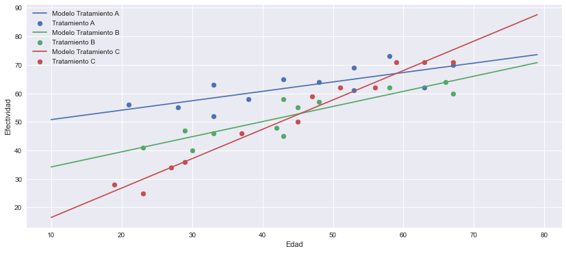

```python
# Graficamos el ajuste de las rectas para cada uno de los tratamientos
plt.plot(x, [tA(i) for i in x])
plt.scatter(df1.x1, df1.y)

plt.plot(x, [tB(i) for i in x])
plt.scatter(df2.x1, df2.y)

plt.plot(x, [tC(i) for i in x])
plt.scatter(df3.x1, df3.y)

plt.legend(['Modelo Tratamiento A', 'Tratamiento A',
            "Modelo Tratamiento B", 'Tratamiento B',
            "Modelo Tratamiento C", 'Tratamiento C'])
plt.xlabel("Edad")
plt.ylabel("Efectividad")
```

## Reducción del Modelo

Para poder reducir el modelo, es necesario verificar:

1. ¿El modelo tiene sentido? (interpretar la prueba asociada a la tabla ANOVA). Se plantea la prueba de hipótesis:

$H_0 : \beta_1 = \beta_2 = \cdots = \beta_5 = 0 \text{ v.s. } H_1 : \beta_i \neq 0, \text{ para alguna } i = 1, \dots , 5. $

Matricialmente (prueba lineal general):

$$H_0: \begin{pmatrix} 0 & 1 & 0 & 0 & 0 & 0\\ 0 & 0 & 1 & 0 & 0 & 0\\ 0 & 0 & 0 & 1 & 0 & 0\\ 0 & 0 & 0 & 0 & 1 & 0\\ 0 & 0 & 0 & 0 & 0 & 1 \end{pmatrix}\begin{pmatrix} \beta_0 \\ \beta_1 \\ \beta_2 \\ \beta_3 \\ \beta_4\\ \beta_5 \end{pmatrix} = \begin{pmatrix} 0\\ 0\\ 0\\ 0\\ 0 \end{pmatrix} \text{ v.s. } H_1:\beta \neq 0 \text{ para alguna } i = \left \{ 1, 2, 3, 4, 5 \right \}$$

En pyhton utilizamos el atributo *f_pvalue*.

```python
f = model.f_pvalue
f
```

```
4.264070157904808e-15
```

Por lo tanto, rechazamos la hipotesis nula y aceptamos la alternativa. y concluimos que: Con una confianza del 95% la variable Edad (x1) o los distintos factores de la variable Tratamiento (xA, xB, xC) nos ayudan a modelar el valor promedio de la efectividad del tratamiento, esto es, el modelo tiene sentido.

Forma alternativa de manera matricial

```python
A = np.identity(len(model.params))
A = A[1:, :]
A
```

```
array([[0., 1., 0., 0., 0., 0.],
       [0., 0., 1., 0., 0., 0.],
       [0., 0., 0., 1., 0., 0.],
       [0., 0., 0., 0., 1., 0.],
       [0., 0., 0., 0., 0., 1.]])
```

```python
model.f_test(A)
```

```
<class 'statsmodels.stats.contrast.ContrastResults'>
<F test: F=64.04253685100939, p=4.264070157905692e-15, df_denom=30, df_num=5>
```

1. ¿El efecto de la variable Edad (*x1*) es el mismo en los 3 tratamientos? (rectas con la misma pendiente). Se plantea la prueba de hipótesis:

$H_0 : \beta_4 = 0 \text{ y } \beta_5 = 0 \text{ v.s.} H_1 : \beta_4 \neq 0 \text{ o } \beta_5 \neq 0 $.

Matricialmente (prueba lineal general):

$$H_0: \begin{pmatrix} 0 & 0 & 0 & 0 & 1 & 0\\ 0 & 0 & 0 & 0 & 0 & 1 \end{pmatrix}\begin{pmatrix} \beta_0 \\ \beta_1 \\ \beta_2 \\ \beta_3 \\ \beta_4\\ \beta_5 \end{pmatrix} = \begin{pmatrix} 0\\ 0 \end{pmatrix} \text{ v.s. } H_1:\beta_4 \neq 0 \text{ o } \beta_5 \neq 0$$

Para esté apartado lo pasaremos a su lenguaje matricial

```python
A = [[0,0,0,0,1,0], [0,0,0,0,0,1]]

model.f_test(A)
```

```
<class 'statsmodels.stats.contrast.ContrastResults'>
<F test: F=22.83123711361978, p=9.410457463646548e-07, df_denom=30, df_num=2>
```

Por lo tanto rechazamos la hipotesis nula y concluimos que con una confianza del 95%

- $\beta_4 \neq 0 \text{ o } \beta_5 \neq 0$
- El efecto de la variable Edad (x1) es distinto para al menos un factor de la variable Tratamiento, es decir, para algun tratamiento.
- Al menos hay una pendiente que es distinta.
1. Realizamos una prueba de hipótesis simultánea para analizar qué provocó el rechazo de la prueba realizada en 2. Para esto, ocuparemos *R* en *Python*.

Notar que aquí se incluyen las tres hipótesis individuales asociadas a:

$$\begin{cases} H_{0,1}: & \text{ Las pendientes del tratamiento } A \text{ y } B \text{ son iguales} \\ H_{0,2}: & \text{ Las pendientes del tratamiento } A \text{ y } C \text{ son iguales} \\ H_{0,3}: & \text{ Las pendientes del tratamiento } B \text{ y } C \text{ son iguales} \end{cases}$$

En términos de los parametros:

$$\begin{cases} H_{0,1}: & \beta_1 = \beta_1 + \beta_4 \\ H_{0,1}: & \beta_1 = \beta_1 + \beta_5 \\ H_{0,1}: & \beta_1 + \beta_4 = \beta_1 + \beta_5 \end{cases}$$

Es decir,

$$\begin{cases} H_{0,1}: & \beta_4 = 0 \\ H_{0,1}: & \beta_5 = 0 \\ H_{0,1}: & \beta_4 - \beta_5 = 0 \end{cases}$$

Matricialmente

$$H_0: \begin{pmatrix} 0 & 0 & 0 & 0 & 1 & 0\\ 0 & 0 & 0 & 0 & 0 & 1\\ 0 & 0 & 0 & 0 & 1 & -1 \end{pmatrix}\begin{pmatrix} \beta_0\\ \beta_1\\ \beta_2\\ \beta_3\\ \beta_4\\ \beta_5 \end{pmatrix}= \begin{pmatrix} 0\\ 0\\ 0 \end{pmatrix} \text{ v.s. } H_1: \beta_4 \neq 0 \text{ o } \beta_5 \neq 0 \text{ o } \beta_4 -\beta_5 \neq 0$$

En R utilizamos la librería `multcomp`. Trabajaremos con dicha librería de R pero utilizando Python, para lo cual ocuparemos la librería de Python [rpy2](https://rviews.rstudio.com/2022/05/25/calling-r-from-python-with-rpy2/)

```python
import rpy2
print(rpy2.__version__)
```

```
3.5.4
```

Generamos el ajuste del modelo en R

```python
# Mandamos a llamar la estructura de vector en R
# para que podemos utilizarla
from rpy2.robjects import FloatVector

# Importamos una funcion para poder utilizar librerias de R
from rpy2.robjects.packages import importr
# Objetos de R
from rpy2 import robjects

# Consideramos (importamos) las librerias de R que ocuparemos
stats = importr('stats')
base = importr('base')
multcomp = importr('multcomp')
```

[output not shown]

```python
# Convertimos cada una de nuestras variables a un objeto vector de R.
y = FloatVector(df.y)
x1 = FloatVector(df.x1)
xB = FloatVector(df.xB)
xC = FloatVector(df.xC)
```

las variables que hemos definido antes son variables dentro de Python. Requerimos que dichas variables sean variables dentro de R, para lo cual escribimos

```python
# Variables de Python asignadas a variables de R (R objetos)
# dentro de un ambiente global.
# (robjects.globalenv["y"] <- y)
robjects.globalenv["y"] = y
robjects.globalenv["x1"] = x1
robjects.globalenv["xB"] = xB
robjects.globalenv["xC"] = xC
```

```python
# Realizamos el ajuste del modelo utilizando la libreria stats de R
# como si fuera una libreria de Python
Ajuste = stats.lm(formula = "y ~ x1 + xB + xC + x1:xB + x1:xC")
```

Si bien el modelo anterior ya lo habíamos generado, éste fue generado en un ambiente de Python, lo que hacemos ahora es generar el ajuste del modelo en un ambiente de R. Continuando

```python
# Summary del ajuste
print(base.summary(Ajuste))
```

[output not shown]

[output cut: 37 more lines]

```

Coefficients:
             Estimate Std. Error t value Pr(>|t|)
(Intercept)  47.51559    3.82523  12.422 2.34e-13 ***
x1            0.33051    0.08149   4.056 0.000328 ***
xB          -18.59739    5.41573  -3.434 0.001759 **
xC          -41.30421    5.08453  -8.124 4.56e-09 ***
x1:xB         0.19318    0.11660   1.657 0.108001
x1:xC         0.70288    0.10896   6.451 3.98e-07 ***
---
Signif. codes:  0 '***' 0.001 '**' 0.01 '*' 0.05 '.' 0.1 ' ' 1

Residual standard error: 3.925 on 30 degrees of freedom
Multiple R-squared:  0.9143,	Adjusted R-squared:  0.9001
F-statistic: 64.04 on 5 and 30 DF,  p-value: 4.264e-15
```

Procedemos a crear una matriz de R para poder realizar la prueba simultánea

```python
# Objeto que "vive" en Python pero es de R
K = robjects.FloatVector([0,0,0,0,0,0,0,0,0,0,0,0,1,0,1,0,1,-1])
# Objeto de R
K = robjects.r['matrix'](K, ncol=6, nrow=3)
print(K)

# Objeto que "vive" en Python pero es de R
m = robjects.FloatVector([0,0,0])
# Objeto de R
m = robjects.r['matrix'](m, ncol=1)
print(m)
```

```
     [,1] [,2] [,3] [,4] [,5] [,6]
[1,]    0    0    0    0    1    0
[2,]    0    0    0    0    0    1
[3,]    0    0    0    0    1   -1

     [,1]
[1,]    0
[2,]    0
[3,]    0
```

Alternativa de lo anterior:

```
robjects.globalenv["K"] = K
robjects.globalenv["m"] = m
```

Continuando

```python
# Realizamos la prueba lineal general para pruebas simultáneas
print(base.summary(multcomp.glht(Ajuste, linfct=K, rhs=m)))

# base: R base
```

[output not shown]

[output cut: 28 more lines]

```
    if (ret.y)
        z$y <- y
    if (!qr)
        z$qr <- NULL
    z
})(formula = "y ~ x1 + xB + xC + x1:xB + x1:xC")

Linear Hypotheses:
       Estimate Std. Error t value Pr(>|t|)
1 == 0   0.1932     0.1166   1.657    0.238
2 == 0   0.7029     0.1090   6.451   <0.001 ***
3 == 0  -0.5097     0.1104  -4.617   <0.001 ***
---
Signif. codes:  0 '***' 0.001 '**' 0.01 '*' 0.05 '.' 0.1 ' ' 1
(Adjusted p values reported -- single-step method)
```

Fijando $\alpha = 0,05$, obtenemos los siguientes resultados de forma simultanea:

1. pvalue = 0,238 > 0,05, asociado a la hipótesis $H_{01} : \beta_4 = 0$. No se rechaza H01 por lo tanto no hay evidencia estadística suficiente para considerar que $\beta_4 \neq 0$, de este modo, es plausible identificar que $\beta_4 = 0$.
2. pvalue = 0,001 < 0,05, asociado a la hipótesis $H_{02} : \beta_5 = 0$. Se rechaza H02 por lo tanto hay evidencia estadística suficiente para considerar que $\beta_5 \neq 0$
3. pvalue = 0,001 < 0,05, asociado a la hipótesis $H_{03} : \beta_4 − \beta_5 = 0$. Se rechaza $H_{02}$ por lo tanto hay evidencia estadística suficiente para considerar que $\beta_4 \neq \beta_5$. En otras palabras, de forma simultánea las pendientes asociadas a los tratamientos A y B podrían ser las mismas y por otro lado es posible asumir que la pendiente asociada al tratamiento C es distinta tanto a la pendiente del tratamiento A como a la pendiente del tratamiento B.

Por lo tanto,

$\hat{\mathbb{E}}\left [ y_i; Tratamiento, Edad \right ] = \hat{\beta}_0 +\hat{\beta}_1x_{i,1} + \hat{\beta}_2x_{i,B} + \hat{\beta}_3x_{i,C} + \hat{\beta}_5x_ix_{i,C}$

## Modelo reducido

Consideramos entonces el ajuste del modelo reducido, regresamos a programar solo en "Python".

```python
# Ajuste del modelo reducido
model_r = ols('y ~ x1 + xB + xC + x1:xC', data=df).fit()

sm.stats.anova_lm(model, typ=2)
```

|  | sum_sq | df | F | PR(>F) |
| --- | --- | --- | --- | --- |
| x1 | 3302.258622 | 1.0 | 214.363829 | 3.331105e-15 |
| xB | 602.599365 | 1.0 | 39.117320 | 6.862837e-07 |
| xC | 620.533401 | 1.0 | 40.281495 | 5.311571e-07 |
| x1:xB | 42.282024 | 1.0 | 2.744708 | 1.080006e-01 |
| x1:xC | 641.064054 | 1.0 | 41.614229 | 3.982473e-07 |
| Residual | 462.147738 | 30.0 | NaN | NaN |

```python
# Parametros obtenidos del ajuste del modelo
model_r.params
```

```
Intercept    43.285243
x1            0.424864
xB          -10.027208
xC          -37.073862
x1:xC         0.608526
dtype: float64
```

```python
 print(model_r.summary())
```

```
                            OLS Regression Results
==============================================================================
Dep. Variable:                      y   R-squared:                       0.907
Model:                            OLS   Adj. R-squared:                  0.894
Method:                 Least Squares   F-statistic:                     75.14
Date:                Tue, 27 Sep 2022   Prob (F-statistic):           1.68e-15
Time:                        10:00:30   Log-Likelihood:                -98.600
No. Observations:                  36   AIC:                             207.2
Df Residuals:                      31   BIC:                             215.1
Df Model:                           4
Covariance Type:            nonrobust
==============================================================================
                 coef    std err          t      P>|t|      [0.025      0.975]
------------------------------------------------------------------------------
Intercept     43.2852      2.927     14.787      0.000      37.315      49.255
x1             0.4249      0.060      7.093      0.000       0.303       0.547
xB           -10.0272      1.648     -6.085      0.000     -13.388      -6.667
xC           -37.0739      4.519     -8.204      0.000     -46.290     -27.858
x1:xC          0.6085      0.095      6.374      0.000       0.414       0.803
==============================================================================
Omnibus:                        2.617   Durbin-Watson:                   1.804
Prob(Omnibus):                  0.270   Jarque-Bera (JB):                1.661
Skew:                          -0.284   Prob(JB):                        0.436
Kurtosis:                       2.113   Cond. No.                         369.
==============================================================================

Notes:
[1] Standard Errors assume that the covariance matrix of the errors is correctly specified.
```

## Verificación de supuestos

- Linealidad. Veamos un gráfico sobre regresiones ajustadas respecto a la eficacia y a cada una de las variables involucradas en el modelo reducido:

[output not shown]

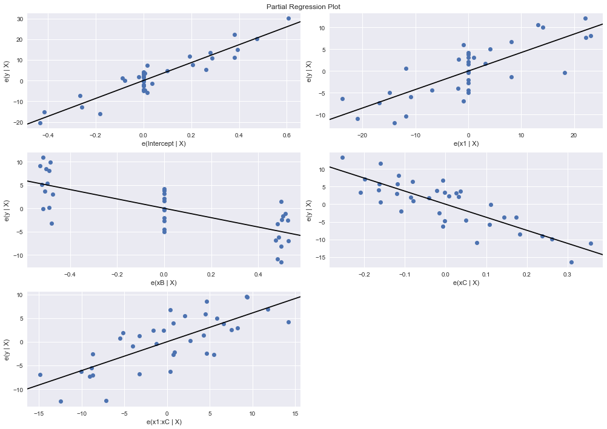

```python
plt.rcParams['figure.figsize'] = [14, 10]
# Graficos: variable independiente vs variables dependientes
fig = sm.graphics.plot_partregress_grid(model_r)
fig.tight_layout(pad=1.0)
```

- Normalidad. Checamos con el histograma de la distribución de los residuos

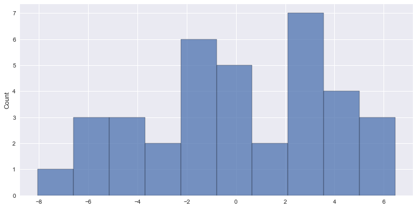

```python
plt.rcParams['figure.figsize'] = [12, 6]
sns.histplot(model_r.resid, bins = 10)
plt.show()
```

Lo cual no nos brinda alguna información relevante sobre la distribución de los residuales. Mejoramos el gráfico anterior, pero antes calculamos la media y la desviación estándar de los residuales

```python
from scipy import stats as st
mu, std = st.norm.fit(model_r.resid)
mu, std
```

```
(6.17777434146976e-14, 3.743252307963197)
```

Luego:

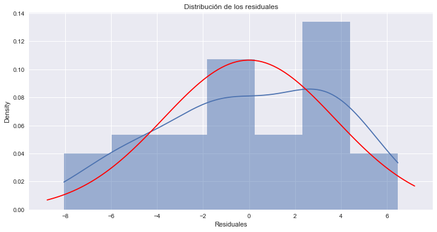

```python
fig, ax = plt.subplots()

# Grafico de los residuales:
# histograma junto con la densidad
sns.histplot(x=model_r.resid, ax=ax, stat="density", linewidth=0, kde=True)
ax.set(title="Distribución de los residuales", xlabel="Residuales")

# Grafico correspondiente a una densidad proveniente de una distribucion
# normal (mu, std^2)
xmin, xmax = plt.xlim() # valores maximos para el intervalo de graficacion del eje X
x = np.linspace(xmin, xmax, 100) # generamos algunos valores para la x
p = st.norm.pdf(x, mu, std) # Funcion de densidad obtenida de una normal (mu, std^2)
sns.lineplot(x=x, y=p, color="red", ax=ax) # Graficamos la densidad anterior
plt.show()
```

Lo cual, al parecer, nos da indicios de que la distribución de los residuales no se distribuye normal. Completamos mediante el gráfico de Q-Qplot

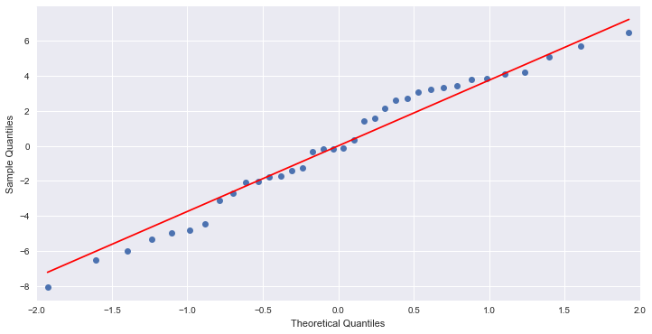

```python
sm.qqplot(model_r.resid, line='s');
```

Al parecer los datos sí se están distribuyendo normal.

Pero recordemos que los gráficos solo nos da un idea detras del comportamiento, si queremos mayor certeza deberemos de aplicar pruebas de hipótesis.

**Pero las graficas no garantizan nada**

Los test Shapiro-Wilk test y D'Agostino's K-squared test son dos de los test de hipótesis más empleados para analizar la normalidad. En ambos, se considera como hipótesis nula que los datos proceden de una distribución normal.

El p-value de estos test indica la probabilidad de obtener unos datos como los observados si realmente procediesen de una población con una distribución normal con la misma media y desviación que estos. Por lo tanto, si el p-value es menor que un determinado valor (típicamente 0.05), entonces se considera que hay evidencias suficientes para rechazar la normalidad.

```python
# Shapiro-Wilk test
# ==============================================================================
shapiro_test = st.shapiro(model_r.resid)
shapiro_test
```

```
ShapiroResult(statistic=0.9656770825386047, pvalue=0.319449245929718)
```

```python
# D'Agostino's K-squared test
# ==============================================================================
k2, p_value = st.normaltest(model_r.resid)
print(f"Estadístico = {k2}, p-value = {p_value}")
```

```
Estadístico = 2.6169126708165154, p-value = 0.27023688969450765
```

**Por lo tanto, los residuales tienen distribución normal**.

- Homocedasticidad

La suposición de homoscedasticidad es una suposición vital. Si esta suposición es violada, entonces los errores estándar serán sesgados. Los errores estándar se utilizan para realizar pruebas de significación y calcular los intervalos de confianza.

Esto puede ser probado usando un residual vs. valores ajustados, mirando un gráfico de dispersión (si una forma de como está presente entonces heteroscedasticidad está presente), o mediante el uso de una prueba estadística como Bruesch-Pagan, prueba de Cook-Weisberg, o prueba general blanca. En este ejemplo, se utilizará la prueba Bruesch-Pagan.

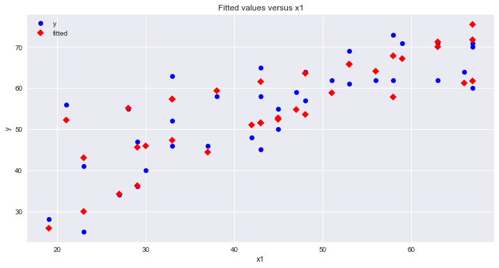

```python
sm.graphics.plot_fit(model_r, 1, vlines=False);
```

```python
import statsmodels.stats.diagnostic as sms
name = ['Lagrange multiplier statistic', 'p-value',
        'f-value', 'f p-value']
test = sms.het_breuschpagan(model.resid, model.model.exog)
result = zip(name, test)
print(list(result))
```

```
[('Lagrange multiplier statistic', 2.9958191453619496), ('p-value', 0.7006304411123819), ('f-value', 0.5446253900782909), ('f p-value', 0.740988751661612)]
```

entonces sí se está cumpliendo el supuesto de la homocedasticidad.

## Algunas preguntas

**¿La efectividad media de los tres tratamientos es la misma para todas las edades?**

```python
A = [[0,0,1, 0,0],
    [0,0,0, 1,0],
    [0,0,0, 0,1],
    [0,0,1,-1,0]]
A
model_r.f_test(A)
```

```
<class 'statsmodels.stats.contrast.ContrastResults'>
<F test: F=30.034106752500577, p=2.663200219438571e-09, df_denom=31, df_num=3>
```

**¿El efecto de la edad en la efectividad media es la misma para los tres tratamientos?**

```python
A = [[0,0,0,0,1]]
A
model_r.f_test(A)
```

```
<class 'statsmodels.stats.contrast.ContrastResults'>
<F test: F=40.63101538056917, p=4.2498150170287766e-07, df_denom=31, df_num=1>
```

## Ejercicio

Considere el archivo *Ejercicio_ANCOVA*.

1. Realice un analisis descriptivo.
2. Ajuste un modelo ANCOVA.
3. De una intepretación a los resultados.
4. Vea si se puede reducir el modelo, en caso de que se pueda reducir verifique los supuestos.

Todo lo anterior deberá ser realizado en *PYTHON*.